# SI 650 / EECS 549 Project Blog Post

Yanyu Long, longyyu@umich.edu

December 16, 2020

# Building a search engine for your favorite TV show from scratch

## I. Introduction

This project builds a vertical search engine for scripts of Friends, the popular American TV sitcom. The search engine allows fans of the TV show to search for classic quotes or locate the episodes that some beloved characters/items showed up in, and provides ample information for users to recall the classic scenes.

From this project, you can learn to:

- implement your own search engine that can be applied to ANY dataset;
- evaluate the performance of ranking functions to find the model that works best.

Feel free to fork [the project’s Github repo](https://github.com/longyyu/friends-search-engine) or visit and interact with the [web app](http://longyyu.pythonanywhere.com/)!

## II. Data

#### Data Source

The Friends Corpus is a collection of all the conversations that occurred over 10 seasons of Friends. It is available at the Github repository emorynlp/character-mining under directory `json`. Let’s have a look at the original data format.

```
{
  "season_id": "s01",
  "episodes": [
    {
      "episode_id": "s01_e01",
      "scenes": [
        {
          "scene_id": "s01_e01_c01",
          "utterances": [
            {
              "utterance_id": "s01_e01_c01_u001",
              "speakers": [
                "Monica Geller"
              ],
              "transcript": "There's nothing to tell! He's just some guy I work with!",
              "tokens": [
                [
                  "There",
                  "'s",
                  "nothing",
                  "to",
                  "tell",
                  "!"
                ],
                [
                  "He",
                  "'s",
                  "just",
                  "some",
                  "guy",
                  "I",
                  "work",
                  "with",
                  "!"
                ]
              ],
              "transcript_with_note": null,
              "tokens_with_note": null,
              "character_entities": [
                [],
```

[output cut: 17 more lines]

```
              ]
            },
            {
              "utterance_id": "s01_e01_c01_u002",
              "speakers": [
                "Joey Tribbiani"
              ],
              "transcript": "C'mon, you're going out with the guy! There's gotta be something wrong with him!",
              "tokens": [
                [
                  "C'mon",
                  ",",
                  "you",
                  "'re",
                  "going",
```

The corpus data can be divided by seasons, episodes, scenes, and utterances. I decided to treat each utterance as a document (i.e., the unit of retrieved results will be utterances), because users are most likely searching for classic quotes, which are generally short.

The following code snippet shows how to extract the `utterance_id`, `speakers`, and `transcript` values from the original data.

```python
idx = 0
for episode in season['episodes']:
  for scene in episode['scenes']:
    for utterance in scene['utterances']:
      if utterance['tokens']: # pass the empty utterances
        df_all_transcript.iloc[idx] = dict(
          u_id = utterance['utterance_id'],
          speakers = ', '.join(utterance['speakers']),
          transcript = utterance['transcript']
        )
        idx += 1
```

Looping over 10 seasons, we can collect 61,309 non-empty utterances and store it in a TSV file. The `transcript` column alone is enough for building a search engine, but the `u_id` and `speakers` can be useful in the user interface to make the retrieval results more informative.

**Table 1.** The pre-processed Friends corpus data

| Utterance ID | Speakers | Transcript |
| --- | --- | --- |
| s01_e01_c01_u001 | Monica Geller | There’s nothing to tell! He’s just some guy I work with! |
| s01_e01_c01_u002 | Joey Tribbiani | C’mon, you’re going out with the guy! There’s gotta be something wrong with him! |
| s01_e01_c01_u003 | Chandler Bing | All right Joey, be nice. So does he have a hump? A hump and a hairpiece? |
| s01_e01_c01_u004 | Phoebe Buffay | Wait, does he eat chalk? |
| s01_e01_c01_u006 | Phoebe Buffay | Just, ’cause, I don’t want her to go through what I went through with Carl- oh! |
| s01_e01_c01_u007 | Monica Geller | Okay, everybody relax. This is not even a date. It’s just two people going out to dinner and- not having sex. |

## III. Methods

### The retrieval algorithm

The retrieval algorithm is implemented in the class `Indexes`, which can be found in the `inverted_index.py` in the project’s repo. I won’t elaborate on the concept of inverted index. Instead, I think it would be more helpful if we start from the intuition:

> The retrieval algorithm is essentially about **building a ranking function** that is able to score each document given a query. The score can be interpreted as the similarity between the query and the documents, or the extent to which a document is a good match. After that, we can rank all the documents in descending order of the score, and the top ranked documents will be returned as retrieval results.  
> And the `Indexes` class, or the **inverted index**, is used to compute the necessary statistics and variables that the ranking functions will need.

#### Ranking functions

There are various forms of ranking functions. We only need one to create a functional search engine, but it can be helpful to look at a few more formulas and understand the intuitive behind them. Description of the notations are in table 3.

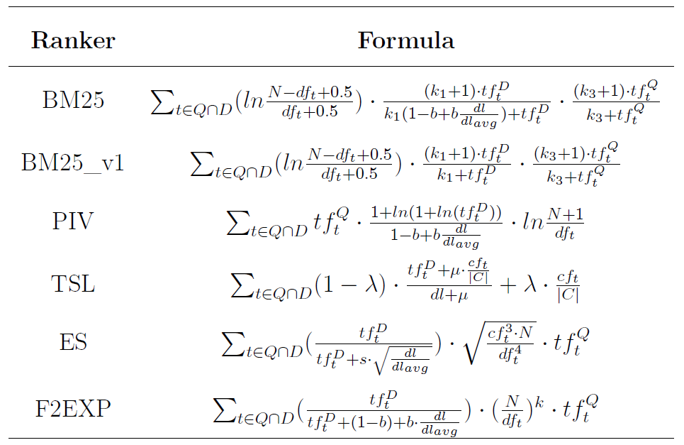

**Table 2.** Formulas of ranking functions

It can be observed that all the ranking functions start with the summation $\sum_{t \in Q \cap D}$ . This means that we go through every term in the intersection of the query $Q$ and the document $D$, and compute what’s inside that summation. The following code snippet shows the method `score_bm25` and `score_f2exp` in the class `Indexes` (see the `inverted_index.py` in the Github repo). These methods are essentially calculating what’s inside the summation, given a query and a document.

```python
  def score_bm25(self, term, doc_id, k1 = 1.25, b = 0.75, k3 = 500):
    df_term = self.doc_freq[term]
    tf_term_doc = self.term_to_freq_pos[(doc_id, term)][0]
    qtf_term_query = self.query_term_freq[term]

    score_idf = math.log((self.doc_count - df_term + 0.5) / (df_term + 0.5))
    score_tf = ((k1 + 1) * tf_term_doc /
                (k1 * (1 - b + b * self.doc_length[doc_id] /
                self.avg_doc_length) + tf_term_doc))
    score_qtf = ((k3 + 1) * qtf_term_query) / (k3 + qtf_term_query)
    return(score_idf * score_tf * score_qtf)

  def score_f2exp(self, term, doc_id, k = 0.35, b = 0.5):
    score_idf = (self.doc_count / self.doc_freq[term])**k
    tf_term_doc = self.term_to_freq_pos[(doc_id, term)][0]
    score_tf = (tf_term_doc / (tf_term_doc + (1 - b) + \
                b * self.doc_length[doc_id] / self.avg_doc_length))
    score_qtf = self.query_term_freq[term]
    return(score_idf * score_tf * score_qtf)
```

#### Inverted index

We can observe from the above formulas that the ranking functions use a similar set of variables.

**Table 3.** Variables used by the ranking functions

| Notation | Description |
| --- | --- |
| $t$ | term |
| $D$ | document |
| $Q$ | query |
| $N$ | the number of documents in the entire collection |
| $C$ | the number of unique terms in the entire collection |
| $tf_t^D$ | the frequency of term $t$ in document $D$ |
| $tf_t^Q$ | the frequency of term $t$ in query $Q$ |
| $cf_t$ | the frequency of term $t$ in the entire collection of $N$ documents |
| $dl_{avg}$ | average document length |
| $dl$ | the length of the current document $D$ |
| $df_t$ | the number of documents with term $t$ |

The intuitive behind the design of the class `Indexes` is to process the corpus data (i.e., the utterances we extracted), and compute all the variables that a ranker needs to score documents.

The variables are generally easy to compute. The most complex computation here is for the term frequency in document $tf_t^D$, which is stored in `self.term_to_freq_pos`, and the document frequency of a term $df_t$, `self.doc_freq`.

`self.term_to_freq_pos` is a dictionary that maps a tuple of (doc_id, term) to a list of [frequency, position].

```python
def generate_inverted_index(self):
  self.term_to_freq_pos = dict()
  for idx, doc_id in enumerate(self.doc_id):
    # update posting (self.term_to_freq_pos)
    for pos, term in enumerate(self.doc_tokens[doc_id]):
      if term in self.stop_list:
        continue
      # update document frequency and position for current term
      if (doc_id, term) not in self.term_to_freq_pos:
        self.term_to_freq_pos[(doc_id, term)] = [0, []]
      self.term_to_freq_pos[(doc_id, term)][0] += 1
      self.term_to_freq_pos[(doc_id, term)][1].append(pos)
```

**`Example: self.term_to_freq_pos`**

```
{
  ('s03_e01_c09_u002', 'music'): [1, [11]],
  ('s03_e01_c09_u002', 'okay'): [2, [13, 27]],
  ('s03_e01_c09_u002', 'close'): [1, [16]],
  ('s03_e01_c09_u002', 'you'): [1, [17]],
  ('s03_e01_c09_u002', 'eyes'): [1, [18]]),
  ...
}
```

`self.doc_freq` is a dictionary that maps a term to the number of documents that contain it.

```python
def compute_doc_freq(self):
  # turn the posting into a data.frame
  posting_df = pd.DataFrame.from_dict(
    self.term_to_freq_pos, orient = 'index',
    columns = ["freq", "pos"]
  )
  docid_term = list(zip(*posting_df.index))
  posting_df['doc_id'] = docid_term[0]
  posting_df['term'] = docid_term[1]
  posting_df = posting_df.reset_index(drop = True)\
    [["doc_id", "term", "freq", "pos"]]\
    .sort_values(by = "doc_id")

  # create a dictionary base on posting_df
  dictionary_df = posting_df.pivot_table(
    index = 'term', values = ['doc_id', 'freq'],
    aggfunc = {'doc_id': 'count', 'freq': np.sum}
  ).reset_index()\
  .rename(columns = {'doc_id': 'doc_freq', 'freq': 'total_freq'})
  # update self.doc_freq
  self.doc_freq = dict(
    zip(dictionary_df['term'], dictionary_df['doc_freq'])
  )
```

**`Example: self.doc_freq`**

```
{
  "adam": 7,
  "adams": 4,
  "add": 11,
  "added": 9,
  "addict": 4,
  "addicted": 2,
  "adding": 3,
  "additional": 2,
  "address": 18,
  "addressed": 3,
  "addresses": 1,
  "adds": 5,
  "adelaide": 1,
  "adelman": 2,
  "adidas": 1,
  "adios": 1,
  "adirondacks": 1,
  "adjoining": 1,
  "adjusting": 2,
  "adjustment": 1,
  ...
}
```

With these class attributes, we can run the above mentioned ranking functions (e.g. `score_bm25`, `score_f2exp`). Finally, the method `rank_doc` loops over each term in the intersection of a query and a document, and sum up the scores.

```python
for i, doc_id in enumerate(doc_id_list):
  common_tokens = set(query_tokens) & set(self.doc_tokens[doc_id])
  for term in common_tokens:
    doc_score[i] += ranking_func(term, doc_id, **kwargs)
```

### Ranker Evaluation

The retrieval algorithm section has covered the critical steps to build a functioning search engine. If you want to compare the performance of different ranking functions, the effects of different stemmers and stopword lists (though not covered in this article), or to tune the parameters, this section will be helpful for you.

#### Data basis for ranker evaluation

Before introducing the metrics, let’s take a look at the data we need for ranker evaluation: (i) a list of testing queries, (ii) the documents (document ID will suffice here!) retrieved by ranker for each query, (iii) the relevance score for the retrieval results.

In this project, I designed 15 sample queries, and annotated relevance scores for 168 query-document pairs.

**`Testing queries`**

```
She's your lobster
the Geller Cup
We were on a break
Ross Russ
Joey doesn't share food
gum would be perfection
we know they know we know
the last thing I wash and the first thing you wash
Chandler's job
night and later that night
my best friend and my sister
statistical analysis and data reconfiguration
I am a medical marvel
Ben first hi
pink shirt faded salmon
```

**`Relevance score annotation`**

Each line in the annotation data (`/data/friends-qrels.txt`) follows the format: (query_id doc_id relevance_score).

```
0 9003 2
0 9195 1
0 16277 0
0 23458 1
0 39956 0
0 46696 0
0 39974 0
0 39947 0
0 13330 0
0 46590 0
1 13884 2
1 13741 2
1 13740 2
1 6151 0
1 28831 0
```

[output cut: 153 more lines]

If the ranker retrieve a document that has been annotated, we are able to match a relevance score. But it is impossible for us to annotate all possible query-document pairs. When the retrieval results are not annotated, we just assume it is irrelevant (relevance score = 0).

#### Evaluation metrics

With the data ready, we can talk about the formulas and Python implementation of two widely used ranker evaluation metrics: average precision (AP), and normalized discounted cumulative gain (NDCG).

**Average precision (AP)** is calculated as per the following formulas:
$$\begin{aligned}
Precision &= \frac{Num\ of\ retrieved\ \&\ relevant\ docs}{Num\ of\ retrieved\ docs}\\
AP(Q_i) &= \frac{1}{n_i}\sum_{j=1}^{n_i} pre_j
\end{aligned}$$
where $n_i$ is the number of retrieved-relevant documents in a specific query $Q_i$, and $pre_j$ is the precision of the top $j$ retrieved documents.

**`Python code for computing the AP`**

```python
def calc_avg_precision(relevance_score):
  # input - relevance_score: an iterable object with numeric values

  # documents with a relevance score of 1 or 2 are viewed as relevant
  df = pd.DataFrame(dict(
    relevance_binary = [1 if val > 0 else 0 for val in relevance_score]
  ))
  # calculate average precision
  df = df.loc[df.relevance_binary == 1] # filter the relevant documents
  df = df.assign(
    precision = range(1, len(df) + 1) / (df.index + 1)
    # <num of retrieved, relevant docs> / <num of retrieved docs>
  )
  return(df.precision.mean())
```

**NDCG at k** is calculated using the following formulas:
$$\begin{aligned}
&NDCG(Q_i) = \frac{DCG(Q_i)}{IDCG(Q_i)} \\
&DCG_k = rel_1 + \sum_{i = 2}^k \frac{rel_i}{log_2 i}\\
&IDCG_k = irel_1 + \sum_{i = 2}^k \frac{irel_i}{log_2 i}
\end{aligned}$$
where $rel_i$ is the relevance score of the $i_{th}$ retrieved document, and $irel_i$ is the relevance score of the $i_{th}$ item in the ideally ordered results.

**`Python code for computing the NDCG`**

```python
def calc_dcg(relevance_score):
  # input - relevance_score: an iterable object with numeric values
  return(
    np.sum([rel if i == 0 else (rel / math.log(i + 1, 2)) \
            for i, rel in enumerate(relevance_score)])
  )

def calc_ndcg(rel_retrieved, rel_ideal):
  # inputs:
  #   rel_retrieved: an iterable object documenting the relevance score
  #     for retrieved documents
  #   rel_ideal: an iterable object documenting the ideal relevance score
  dcg = calc_dcg(rel_retrieved)
  idcg = calc_dcg(rel_ideal)
  return(dcg / idcg)
```

**Reference:**

> - The Wikipedia page Evaluation measures (information retrieval) covers the definition of various evaluation metrics.
> - [This article](https://medium.com/swlh/rank-aware-recsys-evaluation-metrics-5191bba16832), though using a slightly different NDCG formula than mine, provides great graphical illustration of AP and NDCG, which will help link the formula to the code.

## IV. Results and Discussions

In the retrieval algorithm section, we listed six ranking functions and discussed their implementation. With the ranker evaluation metrics, we can tune the parameters for each of them and compare the rankers’ performance under their best parameters.

#### Parameter tuning

For every model (ranking function + parameter setting), AP and NDCG are calculated for all 15 testing queries, and the average value of AP and NDCG are used as the basis for model evaluation. Let’s look at an example:

**Table 4.** Parameter tuning results: take F2EXP as an example

| Ranker | Parameters | MAP | Avg. NDCG |
| --- | --- | --- | --- |
| f2exp | k=0.05, b=0.30 | 0.965 | 0.858 |
| f2exp | k=0.1, b=0.30 | 0.965 | 0.858 |
| f2exp | k=0.1, b=0.4 | 0.956 | 0.853 |
| f2exp | k=0.2, b=0.30 | 0.949 | 0.883 |
| f2exp | k=0.05, b=0.4 | 0.948 | 0.849 |
| f2exp | k=0.15, b=0.4 | 0.946 | 0.878 |
| f2exp | k=0.15, b=0.30 | 0.942 | 0.875 |
| f2exp | k=0.2, b=0.4 | 0.941 | 0.875 |
| f2exp | k=0.25, b=0.4 | 0.941 | 0.875 |
| f2exp | k=0.3, b=0.4 | 0.935 | 0.883 |

#### Ranker comparison

Considering both the MAP and the average NDCG, the best performing ranker is F2EXP, which reaches a MAP value of 0.965 and a NDCG value of 0.858.  
The TSL ranker had the highest MAP (0.985), but the NDCG was lower than other models (0.682), which means that while most of the relevant documents were retrieved, the order was not satisfactory.

**Table 5.** Mean AP and NDCG for different rankers with their best-performing parameters

| Ranker | Parameters | MAP | Avg. NDCG |
| --- | --- | --- | --- |
| bm25 | k1=1.80, b=0.75 | 0.936 | 0.839 |
| bm25_v1 | k1=1.00, b=0.6 | 0.843 | 0.768 |
| piv | b=0.4 | 0.932 | 0.836 |
| tsl | mu=6500, lambda=0.9 | 0.985 | 0.682 |
| es | s=0.95 | 0.903 | 0.892 |
| f2exp | k=0.05, b=0.30 | 0.965 | 0.858 |

## V. What’s Next

This project operates on a single TV show and a small-scale ground truth data. With a larger database and more annotated data, it would be meaningful to run more tests and **find out the best stemming / stopping options for TV scripts in general**.

In terms of the web application, the next step can be implementing **pagination**, so that all of the retrieval results can be displayed across multiple pages. Currently, only the top 20 retrieved documents are displayed.  
It would also be interesting to add an **auto-correct** mechanism for queries, like Google’s. This can be implemented using Python’s `difflib` package, with function `get_close_matches` and `SequenceMatcher`.